# Metapopulations Part II: Assumptions and Applications

March 9, 2022

## Four metapopulation models

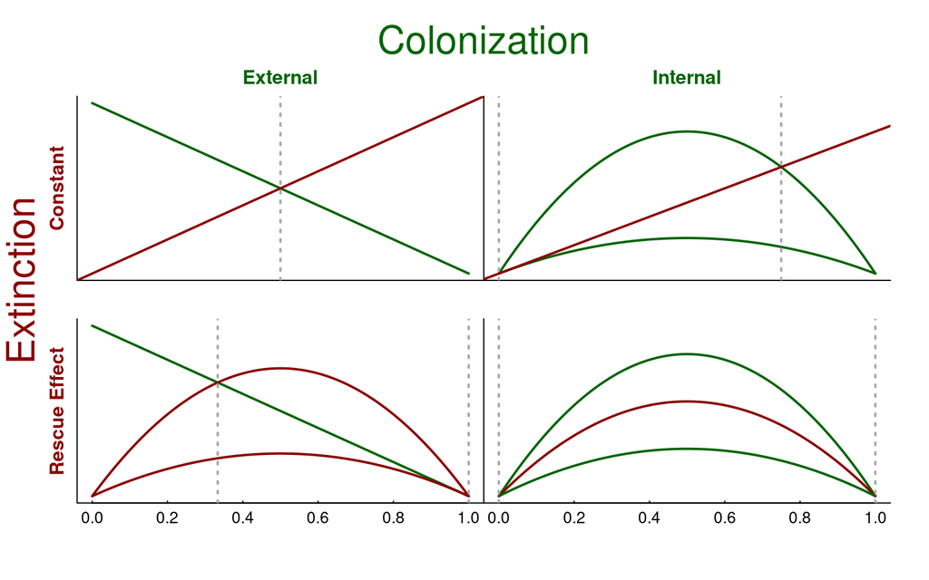

With very different predictions! (Nice synthesis - mainly due to Gotelli.)

## Model predictions:

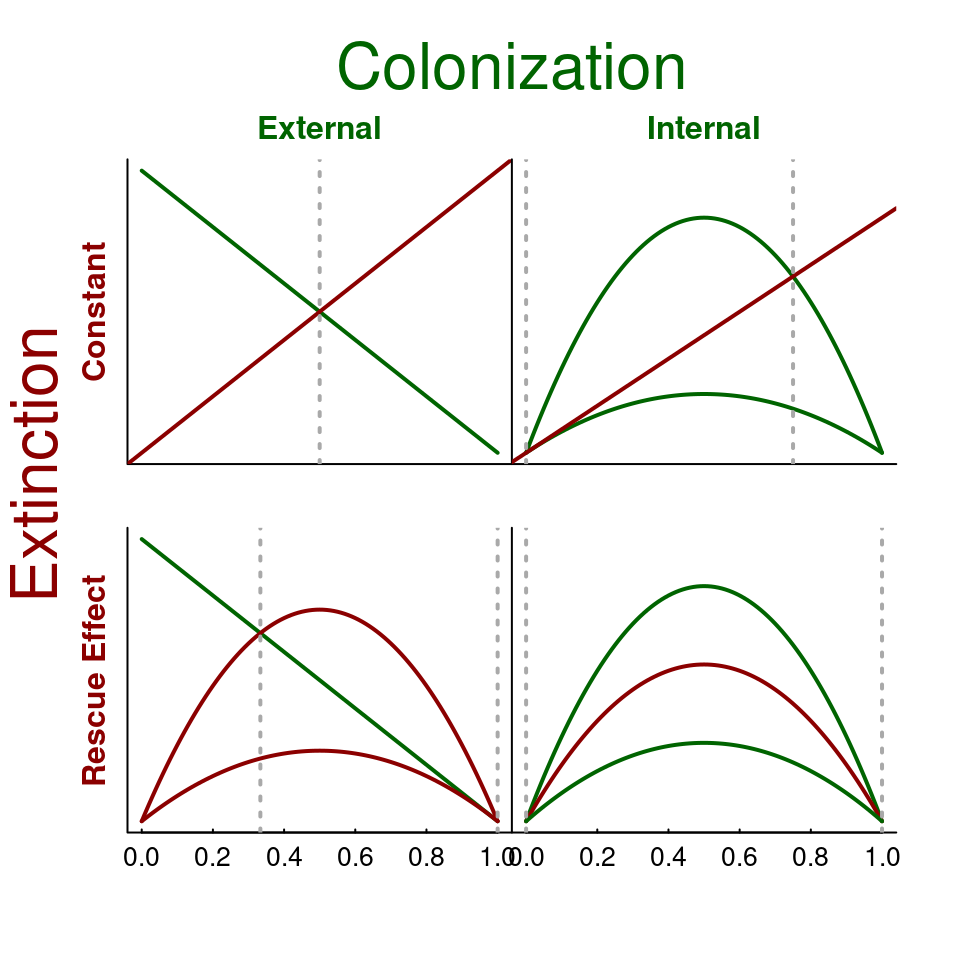

|  | External Colonization | Internal Colonization |
| --- | --- | --- |
| Constant Extinction | \(p_c / (p_c + p_e)\) | 0 or \(1 - {p_e / p_c}\) |
| Rescue Effect | \(p_c/p_e\) or 1 | 0 or 1 |

So … **are metapopulations stable or not!?**

## Theory vs. Reality

**Assumptions**

- “Instantaneous” (binary) population growth - straight to \(K\)
- Homogeneous patch quality
- Homogeneous growth process
- Implicit spatial structure - (all patches affect all others equally)
- Deterministic process

**Complications**

- You can have **none** **some** or **lots** in a patch
- Unique - \(K_i\)
- Unique \(r_i\)
- Neighboring patches are more locally important, some patches are very connected, some are very distant
- Stochasticity is very important, esp. for extinction probabilities

## Which is it!?

**It’s hard to do metapopulation studies!**

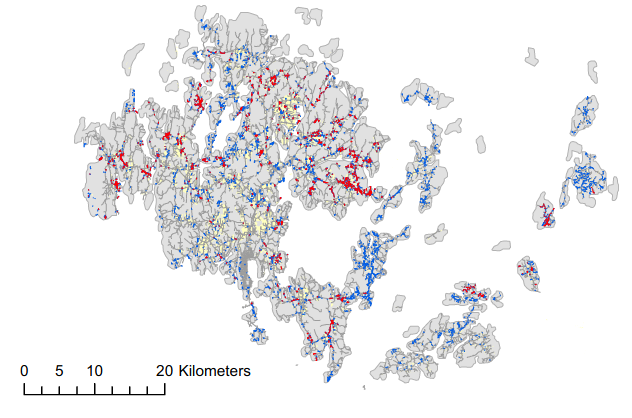

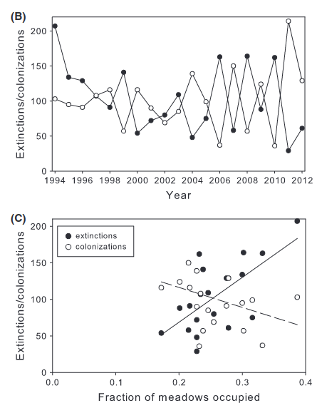

[figure not shown]

## Example 1: Abalone intro

Pinto / northern abalone (*Haliotis Kamtschatkana*) - overharvested commercially in British Columbia, commercial harvest banned, recovering.

**Question: how is “poaching” affecting their recovery?**

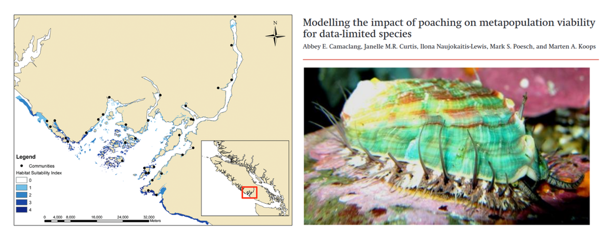

## Example 1: Abalone model

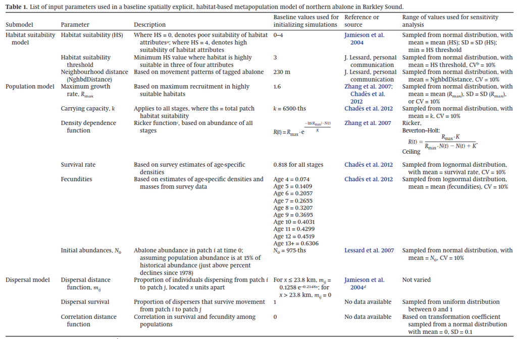

### If you look closely…

- Growth rate \(r\)
- Carrying capacity \(K\)
- Age structured fecundity
- Survival
- Dispersal distances
- Dispersal survival

## Example 1: Abalone results

Used: metapopulation probability of extinction = 0.1 as threshold, corresponding to IUCN definition of Vulnerable.

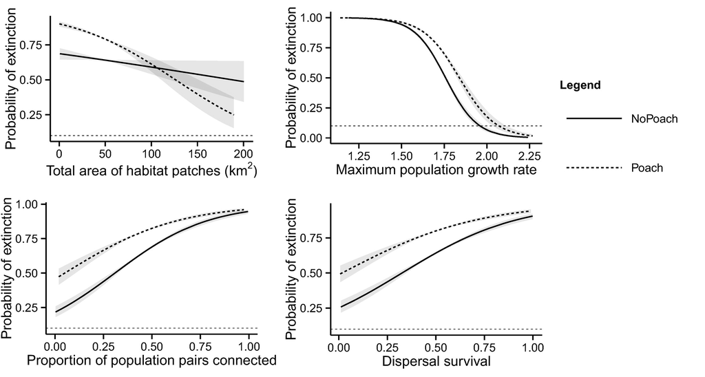

## Metapopulation management

1. Can be challenging because **equilibrium** might not exist!
2. Metapopulation will surely become extinct if patches are removed …
3. … but **facilitating recolonization** and maintaining **large patches** can help.
4. As many fragments as possible should be preserved…
5. … but distances can’t be too large, or no recolonization or rescue effect.
6. Properties of the matrix are important: **corridors** and **stepping stones**.
7. Recolonization has to be observed within a few generations for metapopulations to have a chance.
8. Sizes of patches is important to hedge against demographic stochasticity.

(from: **Hanski, I. 1997. Metapopulation biology. Pp. 69-91. San Diego, USA, Academic Press.**)